# Time Series Analysis with Applications in R - Ch. 12

# Notes from: Time Series Analysis with Applications in R - Ch. 12

2nd Addition, Cryer and Chan, 2008 These notes are mixture of code from the book, my own code, summaries of the text and math shown, and links to other useful resources.

## Time Series Models of Heteroskedasticity

Up to this point it the book discusses the conditional mean structure of time series data. This chapter concerns the conditional variance structure.

Let $\{Y_t\}$ be a time series. The conditional variance of $Y_t$ given past Y’s, i.e. $Y_{t-1},Y_{t-2},...$ measures the uncertainty in the deviation of $Y_t$ from its conditional mean $E(Y_t|Y_{t-1},Y_{t-2},...)$.

If the series follows some ARIMA model, the one step ahead conditional variance equals the noise variance for any present and past values of the process - meaning variance is assumed to be pretty much the same. However in practice, the conditional variance itself may follow a random process. This process may be clustered - hence “conditional heteroskedasticity”.

In finance, conditional variance of the return of a financial asset is often a measure of risk. In the first part of this section we assume the conditional mean (expected return) is zero and the return series should be white noise. Later, models for conditional mean are combined with models of conditional variance.

```r
library(ggplot2)
library(magrittr)
library(TSA)
library(tseries)
```

## Common Features of Financial Time Series

Let $\{p+t\}$ be the time series of daily prices. The continuously compounded return on the t-th day is:
$$r_t=log(p_t)-log(p_{t-1})$$
. Multiplying by 100 allows treatment as a percentage.

Looking at a fund called CREF, there is a pattern of alternating quiet and volatile periods “volatility clustering”.

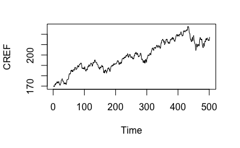

```r
data(CREF)
plot(CREF)
```

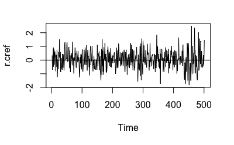

```r
r.cref <- diff(log(CREF)) * 100
plot(r.cref)
abline(h=0)
```

This pattern studies the dynamical pattern in the volatility of a time series (the conditional variance process). The ACF and PACF of the daily returns suggest that the returns have little serial correlation.

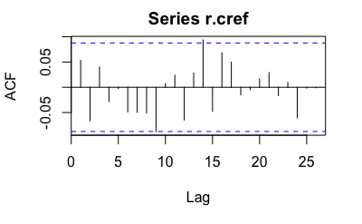

```r
acf(r.cref)
```

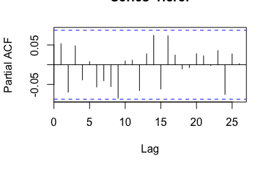

```r
pacf(r.cref)
```

```r
eacf(r.cref)
```

```
AR/MA
  0 1 2 3 4 5 6 7 8 9 10 11 12 13
0 o o o o o o o o o o o  o  o  x
1 x o o o o o o o x o o  o  o  o
2 x x o o o o o o x o o  o  o  o
3 x x o o o o o o o o o  o  o  o
4 x x x o o o o o o o o  o  o  o
5 x x x o x o o o o o o  o  o  o
6 x x x x x o o o o o o  o  o  o
7 x o o x o o x o o o o  o  o  o
```

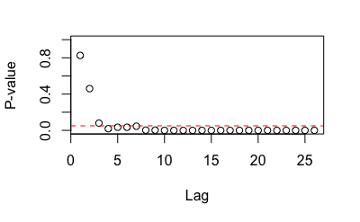

```r
McLeod.Li.test(y=r.cref)
```

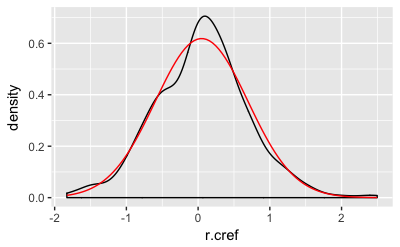

```r
r.cref.df <- as.data.frame(r.cref)
ggplot(r.cref.df, aes(x = r.cref)) + geom_density() + stat_function(fun = dnorm, colour = "red", args = list(mean = mean(r.cref), sd = sd(r.cref)))
```

# The ARCH(1) Model

Autoregressive conditional heteroscedasticity (ARCH) model proposed by Engle (1982) for the changing variance of a time series. As seen by the returns above, financial time series are often serially uncorrelated with mean zero and exhibit volatility clustering.

A return series $\{r_t\}$ is often serially uncorrelated with zero mean. The conditional variance (conditional volatility) of it is $\sigma^2_{t|t-1}$. When $r_t$ is available $r^2_t$ provides an unbiased estimator of the conditional variance. A volatile period is indicated by large squared returns, an non-volatie period by small squared returns. The squaring primarily allows positive and negative returns to be viewed the same way.

The ARCH(1) model assumes the series $r_t$ is generated:
$$r_t=\sigma_{t|t-1}\varepsilon_t$$
$$\sigma^2_{t|t-1}=\omega+\alpha r^2_{t-1}$$

Where $\alpha$ $\omega$ are unknown parameters and $\{\varepsilon_t\}$ is an iid sequence with zero mean and unit variance (aka **innovations**). Another definition of innovations: “represent the new information that is added to the process at each instant”

Each is independent of $r_{t-j}, j= 1,2,...$. The innovation is presumed to have unit variance so that the conditional variance of $r_t$ equals $\sigma^2_{t|t-1}$. See proof on page 286, basically since the expectation of the conditional variance equals one, conditioning on it just gives the return series expectation.

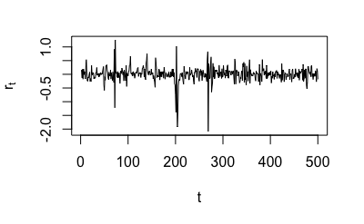

```r
garch01.sim = garch.sim(alpha=c(0.01, 0.9), n = 500)
plot(garch01.sim, type = 'l', ylab = expression(r[t]), xlab = 't')
```

Note the conditional variance is not directly observable, it is a latent variable. This makes the regression analysis more difficult (i.e. finding values for w and a). The conditional variance is hence replaced by:
$$\eta_t=r^2_t-\sigma^2_{t|t-1}$$
Substituting this into the definiton of ARCH(1) above:
$$r^2_t=\omega+\alpha r^2_{t-1}+\eta_t$$
Thus, the squared return series satisfies an AR(1) model under the assumption of an ARCH(1) model of the return series. An ARCH(1) model may be used when an AR(1) model is appropriate for the squared returns.

# GARCH Models

First a general observation: time series modeling is about progressively squeezing as much signal from the data as possible. ARCH(1) looks back one timestep (hence t|t-1). Now we’re going to look back further.